# Analyse des Liens entre Température, Hospitalisations et COVID-19

Michael NYANYUIE, Divin IZERE, Lucky Bernice IKAZE, Mehdi HIMMICHE, Rayane BENCHOKROUN

2024-03-23

## # INTRODUCTION

Cette analyse se penche sur la relation complexe entre les données d’hospitalisation et les variations de température durant la pandémie de COVID-19, couvrant les années 2019 à 2020, avec une perspective comparative des années 2018 et 2021. Elle vise à éclairer sur la manière dont les facteurs environnementaux pourraient corréler avec les tendances de santé publique au cours de l’une des crises sanitaires mondiales les plus difficiles de l’histoire récente.

## OBJECTIFS

Notre étude se fixe les objectifs suivants :

- **Analyser les Tendances d’Hospitalisation** : Examiner les données d’hospitalisation pour extraire des tendances, notamment saisonnières, et comprendre leur influence sur la gestion des crises sanitaires.
- **Évaluer l’Impact des Variations Climatiques** : Étudier l’influence des changements de température sur les taux d’hospitalisation, afin d’établir une possible corrélation entre les conditions météorologiques et la santé publique en période de pandémie.
- **Examiner le Lien entre Soins Intensifs et Mortalité** : Explorer la relation entre le nombre de patients en soins intensifs et le taux de mortalité, afin d’évaluer comment les cas graves influencent les issues fatales.
- **Identifier les Modèles Saisonniers** : Détecter les périodes à risque accru d’hospitalisation et de mortalité, pour mettre en évidence l’importance de la saisonnalité dans la réponse aux crises sanitaires.
- **Utiliser des Méthodes Statistiques Appropriées** : Appliquer des techniques d’analyse statistique rigoureuses, telles que le coefficient de corrélation de Pearson et la régression linéaire, pour une interprétation précise des données.
- **Anticiper l’Impact des Températures sur les Hospitalisations par Régression Linéaire** : Employer la régression linéaire pour prévoir les effets des variations de température sur les taux d’hospitalisation, ajoutant ainsi une composante prédictive à notre étude.

## ACCES A LA BASE DE DONNÉE EN R

```r
library(RMariaDB)

password <- rstudioapi::askForPassword("UT2J Password")
connection <- dbConnect(
  drv = RMariaDB::MariaDB(),
  user = "michael-kofi.nyanyui",
  password = password,
  dbname = "23_2L2_michael_kofi_nyanyuie",
  host = "10.10.190.39",
  port = 3306
)
```

## ## CREATION DE BASE DE DONNÉES.

```r
### TEMPERATURES TABLE
# CREATE TABLE TEMPERATURES(
#   DATE_TEMP DATE,
#   DEP_ID VARCHAR(3),
#   DEPARTMENT VARCHAR(50),
#   MIN_TEMP DECIMAL(10, 2),
#   MAX_TEMP DECIMAL(10, 2),
#   MEAN_TEMP DECIMAL(10, 2),

#   PRIMARY KEY (DATE_TEMP, DEP_ID),
#   FOREIGN KEY (DEP_ID) REFERENCES PROJET_DEP(codeD)
# );

### HOSPITALISATIONS TABLE
# CREATE TABLE HOSPITALISATIONS(
#   DEP_ID VARCHAR(3),
#   SEX INT,
#   DATE_HOSP DATE,
#   NUM_HOSP INT,
#   NUM_INTENSE_CARE INT,
#   NUM_CONV_HOSP INT,
#   NUM_SSR_USLD INT,
#   NUM_OTHERS INT,
#   NUM_RETURN_HOME INT,
#   NUM_DEATHS INT,

#   PRIMARY KEY (DEP_ID, DATE_HOSP, SEX),
#   FOREIGN KEY (DEP_ID) REFERENCES PROJET_DEP (codeD)
# );
```

## VÉRIFICATION DE LA DISTRIBUTION DES DONNÉES

Nous explorons la distribution de nos données pour déterminer si elles suivent une distribution normale, ce qui validerait l’utilisation de méthodes statistiques paramétriques.

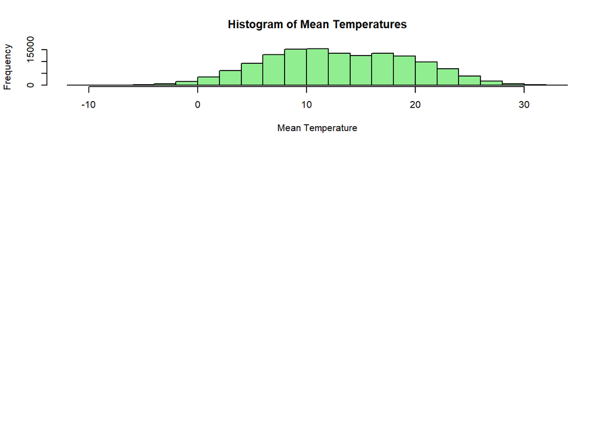

```r
temp_data <- dbGetQuery(
  connection,
  "SELECT MIN_TEMP, MEAN_TEMP, MAX_TEMP
  FROM TEMPERATURES"
)

par(mfrow = c(3, 1)) #3 rows, 1 column


# HIST MEAN_TEMP
hist(
  temp_data$MEAN_TEMP,
  main = "Histogram of Mean Temperatures",
  xlab = "Mean Temperature",
  col = "lightgreen"
)
```

L’observation des histogrammes révèle une forme de courbe en cloche, indiquant une distribution normale des données. Cette caractéristique suggère que la majorité des observations se concentre autour de la moyenne, validant l’utilisation de méthodes statistiques paramétriques pour notre analyse.

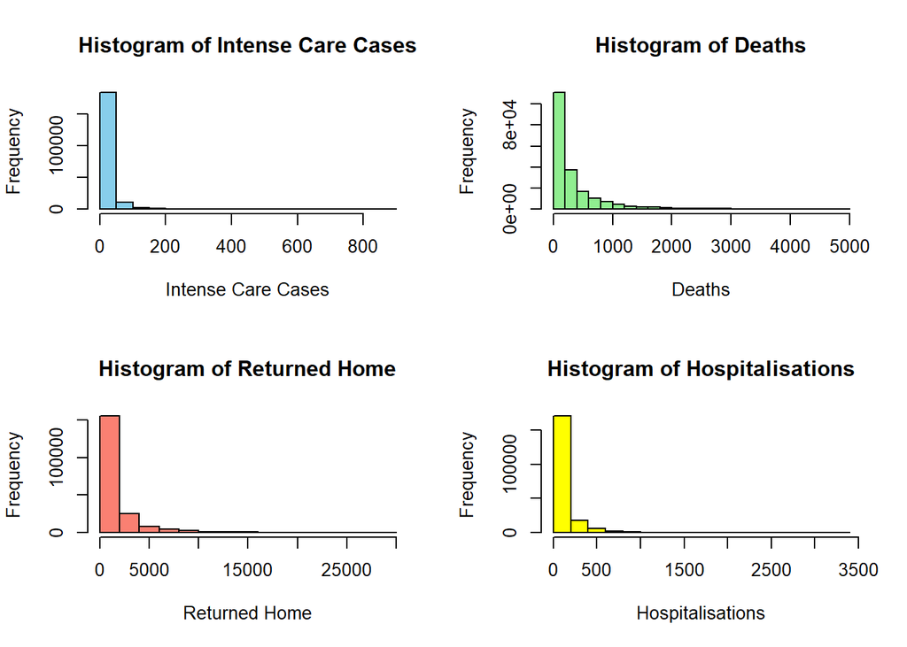

```r
hosp_data <- dbGetQuery(
  connection,
  "SELECT  NUM_INTENSE_CARE, NUM_DEATHS, NUM_RETURN_HOME, NUM_HOSP
  FROM HOSPITALISATIONS"
)

par(mfrow = c(2, 2)) #2 columns 2 rows

# HIST NUM_INTENSE_CARE
hist(
  hosp_data$NUM_INTENSE_CARE,
  main = "Histogram of Intense Care Cases",
  xlab = "Intense Care Cases",
  col = "skyblue"
)

# HISTNUM_DEATHS
hist(
  hosp_data$NUM_DEATHS,
  main = "Histogram of Deaths",
  xlab = "Deaths",
  col = "lightgreen"
)

# HIST NUM_RETURN_HOME
hist(
  hosp_data$NUM_RETURN_HOME,
  main = "Histogram of Returned Home",
  xlab = "Returned Home",
  col = "salmon"
)

# HIST NUM_HOSP
hist(
  hosp_data$NUM_HOSP,
  main = "Histogram of Hospitalisations",
  xlab = "Hospitalisations",
  col = "yellow"
)
```

Les données présentées dans les histogrammes montrent une distribution asymétrique, où les cas de soins intensifs, les décès et les retours à domicile sont concentrés vers les valeurs inférieures de l’axe des abscisses. Cela indique une distribution fortement biaisée à droite, suggérant que la majorité des observations se situent en dessous de la moyenne, avec des valeurs extrêmes qui étirent la queue de la distribution vers des valeurs plus élevées.

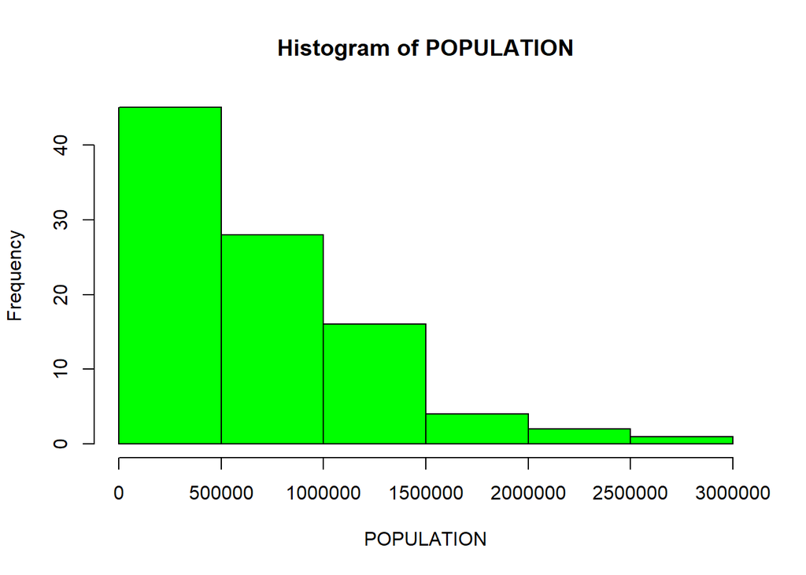

```r
pop_data <- dbGetQuery(
  connection,
  "SELECT total
  FROM PROJET_POPU"
)

# HIST TOTAL POPULATION
hist(
  pop_data$total,
  main = "Histogram of POPULATION",
  xlab = "POPULATION",
  col = "green"
)
```

## ## ETUDE DE VARIABLE HOSPITALISATION

Nous analysons les données d’hospitalisation pour déduire les tendances.

## ETUDE DE TAUX DE CAS INTENSIVES POUR LES DIFFERENTES TRANCHES D’AGES PENDANT LA PANDEMIE

Dans le cadre de cette étude, nous cherchons à identifier les parties de la population les plus impactées par la COVID-19. Pour ce faire, nous analyserons les taux de cas en soins intensifs répartis par tranche d’âge. Ces données nous permettront de construire un histogramme qui mettra en évidence les tranches d’âge les plus affectées.

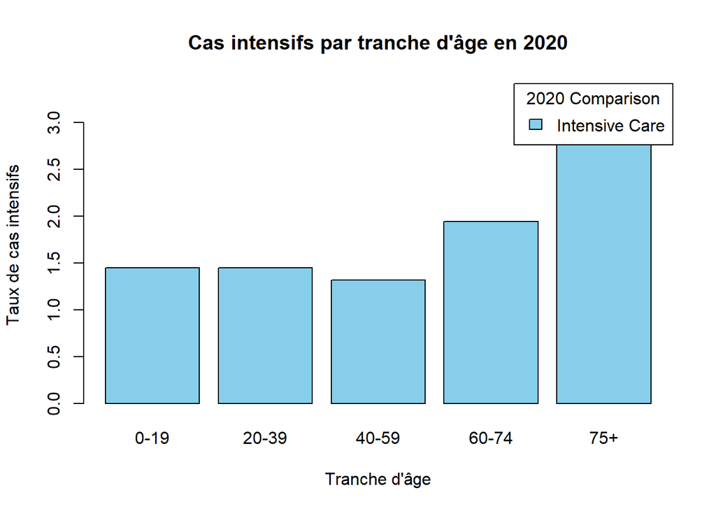

```r
intense_cases_groups <- dbGetQuery(
  connection,
  "SELECT
    (SUM(NUM_INTENSE_CARE) / SUM(age0_19)) * 10000 AS INTENSE_RATE_0_19,
    (SUM(NUM_INTENSE_CARE) / SUM(age20_39)) * 10000 AS INTENSE_RATE_20_39,
    (SUM(NUM_INTENSE_CARE) / SUM(age40_59)) * 10000 AS INTENSE_RATE_40_59,
    (SUM(NUM_INTENSE_CARE) / SUM(age60_74)) * 10000 AS INTENSE_RATE_60_74,
    (SUM(NUM_INTENSE_CARE) / SUM(age75_et_plus)) * 10000
    AS INTENSE_RATE_75_Plus,
    YEAR(DATE_HOSP) AS YEAR_
  FROM HOSPITALISATIONS H
  LEFT JOIN PROJET_POPU P
    ON P.codeD = H.DEP_ID
  WHERE SEX = 0 AND H.DATE_HOSP IS NOT NULL AND YEAR(DATE_HOSP) = 2020
  GROUP BY YEAR(DATE_HOSP)
  "
)

age_groups <- c("0-19", "20-39", "40-59", "60-74", "75+")
intense_cases_2020 <- c(
  intense_cases_groups$INTENSE_RATE_0_19,
  intense_cases_groups$INTENSE_RATE_20_39,
  intense_cases_groups$INTENSE_RATE_40_59,
  intense_cases_groups$INTENSE_RATE_60_74,
  intense_cases_groups$INTENSE_RATE_75_Plus
)

age_groups <- c("0-19", "20-39", "40-59", "60-74", "75+")

barplot(
  height = intense_cases_2020,
  names.arg = age_groups,
  main = "Cas intensifs par tranche d'âge en 2020",
  args.legend = list(title = "2020 Comparison", x = "topright"),
  legend = "Intensive Care",
  xlab = "Tranche d'âge",
  ylab = "Taux de cas intensifs",
  col = "skyblue"
)
```

## ETUDES DE TAUX DE MORTALITE POUR LES DIFFERENTES TRANCHES D’AGES.

Pour répondre à la question posée précédemment, nous utiliserons les taux de mortalité calculés par tranche d’âge. Grâce à ces résultats, nous pourrons déterminer quelle tranche d’âge a subi le plus de décès et en même temps voir si la COVID-19 a eu une influence significative sur le taux de mortalité.

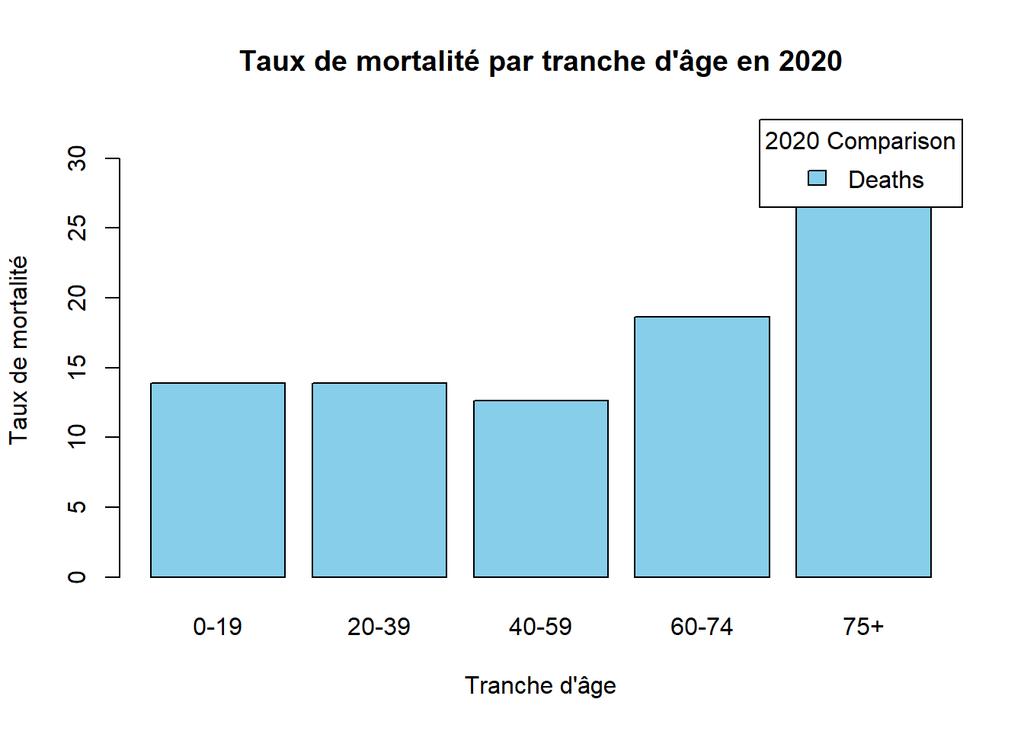

```r
deaths_groups <- dbGetQuery(
  connection,
  "SELECT
    (SUM(NUM_DEATHS) / SUM(age0_19)) * 10000 AS DEATHS_RATE_0_19,
    (SUM(NUM_DEATHS) / SUM(age20_39)) * 10000 AS DEATHS_RATE_20_39,
    (SUM(NUM_DEATHS) / SUM(age40_59)) * 10000 AS DEATHS_RATE_40_59,
    (SUM(NUM_DEATHS) / SUM(age60_74)) * 10000 AS DEATHS_RATE_60_74,
    (SUM(NUM_DEATHS) / SUM(age75_et_plus)) * 10000 AS DEATHS_RATE_75_Plus,
    YEAR(DATE_HOSP) AS YEAR_
  FROM HOSPITALISATIONS H
  LEFT JOIN PROJET_POPU P
    ON P.codeD = H.DEP_ID
  WHERE SEX = 0 AND H.DATE_HOSP IS NOT NULL AND YEAR(DATE_HOSP) = 2020
  GROUP BY YEAR(DATE_HOSP)"
)

deaths_2020 <- c(
  deaths_groups$DEATHS_RATE_0_19,
  deaths_groups$DEATHS_RATE_20_39,
  deaths_groups$DEATHS_RATE_40_59,
  deaths_groups$DEATHS_RATE_60_74,
  deaths_groups$DEATHS_RATE_75_Plus
)

age_groups = c("0-19", "20-39", "40-59", "60-74", "75+")

barplot(
  height = deaths_2020,
  names.arg = age_groups,
  main = "Taux de mortalité par tranche d'âge en 2020",
  args.legend = list(title = "2020 Comparison", x = "topright"),
  legend =  "Deaths",
  xlab = "Tranche d'âge",
  ylab = "Taux de mortalité",
  col = "skyblue"
)
```

### LA CORRELATION ENTRE LE TAUX DE CAS INTENSIFS ET LE TAUX DE MORTALITE POUR LES DIFFERENTES TRANCHES D’AGES EN 2020

Cette analyse vise à explorer la relation entre le taux de cas en soins intensifs et le taux de mortalité afin de déterminer si une corrélation directe existe entre ces deux variables. À travers l’utilisation d’histogrammes, nous chercherons à visualiser la distribution des cas en soins intensifs par rapport aux taux de mortalité correspondants, permettant ainsi une compréhension plus profonde des dynamiques de gravité au sein de la population hospitalisée. Cette méthode statistique nous aidera à identifier visuellement les tendances et à soutenir l’analyse quantitative de la corrélation potentielle.

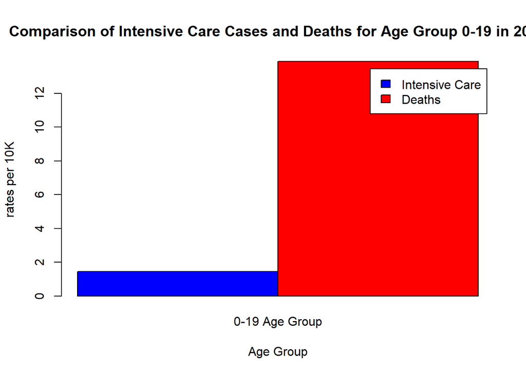

```r
hist_deaths_intense_0_19 <- barplot(
  height = rbind(
    intense_cases_groups$INTENSE_RATE_0_19,
    deaths_groups$DEATHS_RATE_0_19
  ),
  beside = TRUE,
  names.arg = ("0-19 Age Group"),
  col = c("blue", "red"),
  legend = c("Intensive Care", "Deaths"),
  xlab = "Age Group",
  ylab = "rates per 10K",
  main = "Comparison of Intensive Care Cases and Deaths for Age Group 0-19 in 2020"
)
```

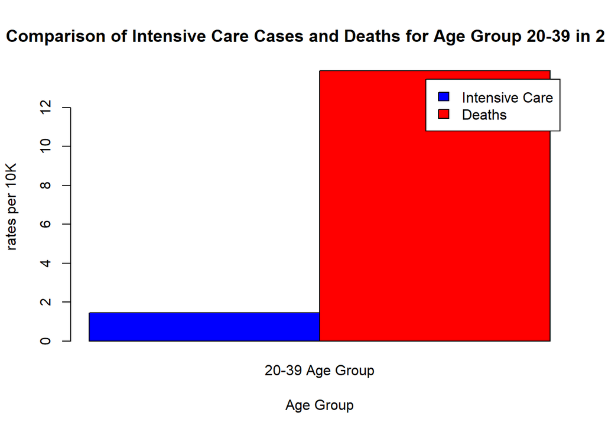

```r
hist_deaths_intense_20_39 <- barplot(
  height = rbind(
    intense_cases_groups$INTENSE_RATE_20_39,
    deaths_groups$DEATHS_RATE_20_39
  ),
  beside = TRUE,
  names.arg = ("20-39 Age Group"),
  col = c("blue", "red"),
  legend = c("Intensive Care", "Deaths"),
  xlab = "Age Group",
  ylab = "rates per 10K",
  main = "Comparison of Intensive Care Cases and Deaths for Age Group 20-39 in 2020"
)
```

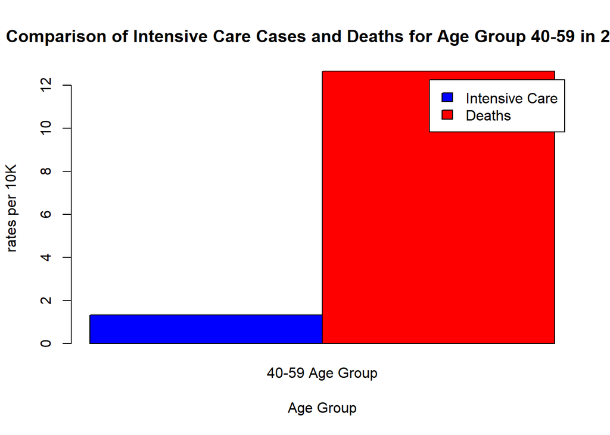

```r
hist_deaths_intense_40_59 <- barplot(
  height = rbind(
    intense_cases_groups$INTENSE_RATE_40_59,
    deaths_groups$DEATHS_RATE_40_59
  ),
  beside = TRUE,
  names.arg = ("40-59 Age Group"),
  col = c("blue", "red"),
  legend = c("Intensive Care", "Deaths"),
  xlab = "Age Group",
  ylab = "rates per 10K",
  main = "Comparison of Intensive Care Cases and Deaths for Age Group 40-59 in 2020"
)
```

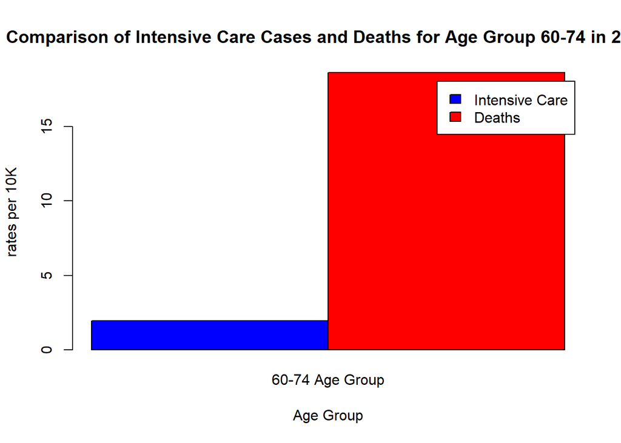

```r
hist_deaths_intense_60_74 <- barplot(
  height = rbind(
    intense_cases_groups$INTENSE_RATE_60_74,
    deaths_groups$DEATHS_RATE_60_74
  ),
  beside = TRUE,
  names.arg = ("60-74 Age Group"),
  col = c("blue", "red"),
  legend = c("Intensive Care", "Deaths"),
  xlab = "Age Group",
  ylab = "rates per 10K",
  main = "Comparison of Intensive Care Cases and Deaths for Age Group 60-74 in 2020"
)
```

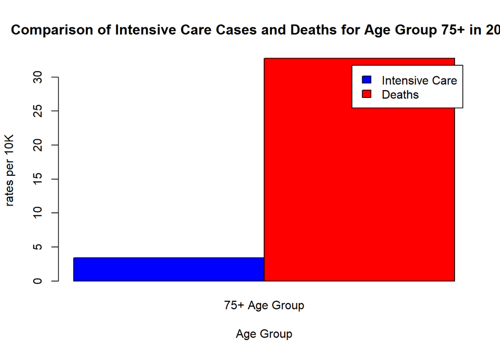

```r
hist_deaths_intense_75_plus <- barplot(
  height = rbind(
    intense_cases_groups$INTENSE_RATE_75_Plus,
    deaths_groups$DEATHS_RATE_75_Plus
  ),
  beside = TRUE,
  names.arg = ("75+ Age Group"),
  col = c("blue", "red"),
  legend = c("Intensive Care", "Deaths"),
  xlab = "Age Group",
  ylab = "rates per 10K",
  main = "Comparison of Intensive Care Cases and Deaths for Age Group 75+ in 2020"
)
```

### ETUDE COMPARATIVE DE TEMPERATURES MOYENNES ET TAUX DE SOINS INTENSIFS PAR REGION

Maintenant que nous avons une vue plus globale concernant le pays par tranches d’âge, pour affiner nos recherches, nous devons déterminer si la température était un facteur majeur influençant les soins intensifs. Pour cela, nous comparerons la région nord de la France, connue pour ses températures basses, avec la région sud, où les températures sont généralement plus élevées, en créant une carte thermique pour mieux visualiser les valeurs. Grâce à cette comparaison, nous pourrons conclure sur l’existence d’un lien entre la température et les taux de mortalité.

```r
library(ggplot2)
library(reshape2)
temps_per_reg <- dbGetQuery(
  connection,
  "SELECT
    CASE
        WHEN R.codeR IN (11, 24, 27, 28, 32, 44, 52, 53) THEN 'NORTH'
        WHEN R.codeR IN (75, 76, 84, 93, 94) THEN 'SOUTH'
    END AS REGS,
    AVG(T.MEAN_TEMP) AS AVG_TEMPS,
    SUM(H.NUM_INTENSE_CARE) / SUM(P.total) * 10000 AS INTENSE_CARE_RATE
  FROM
      PROJET_REG R
  INNER JOIN PROJET_DEP D ON R.codeR = D.codeR
  INNER JOIN (
      SELECT DEP_ID, AVG(MEAN_TEMP) AS MEAN_TEMP
      FROM TEMPERATURES
      WHERE YEAR(DATE_TEMP) = 2020
      GROUP BY DEP_ID
  ) T ON T.DEP_ID = D.codeD
  INNER JOIN (
      SELECT DEP_ID, SUM(NUM_INTENSE_CARE) AS NUM_INTENSE_CARE
      FROM HOSPITALISATIONS
      GROUP BY DEP_ID
  ) H ON H.DEP_ID = D.codeD
  INNER JOIN PROJET_POPU P ON P.codeD = D.codeD
  GROUP BY REGS;"
)

print(temps_per_reg)
```

```
##    REGS AVG_TEMPS INTENSE_CARE_RATE
## 1 NORTH  12.90028          506.1092
## 2 SOUTH  14.19444          434.2434
```

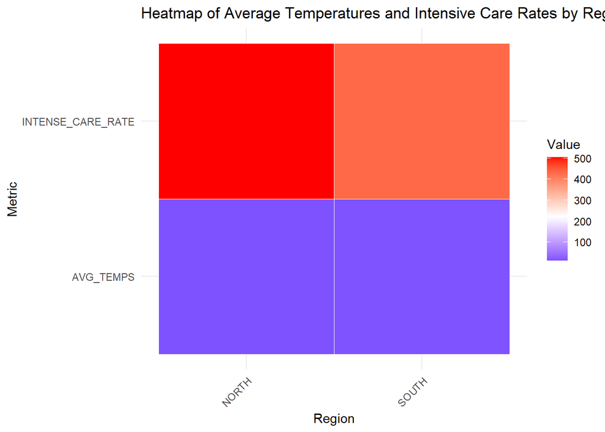

```r
data_long <- melt(temps_per_reg, id.vars = "REGS")

heatmap <- ggplot(data_long, aes(x = REGS, y = variable, fill = value)) +
  geom_tile(color = "white") +
  scale_fill_gradient2(low = "blue", mid = "white", high = "red", midpoint = median(data_long$value, na.rm = TRUE)) +
  labs(title = "Heatmap of Average Temperatures and Intensive Care Rates by Region", x = "Region", y = "Metric", fill = "Value") +
  theme_minimal() +
  theme(axis.text.x = element_text(angle = 45, hjust = 1))


print(heatmap)
```

### LA CORRELATION ENTRE LE TAUX DE CAS INTENSE ET LE TAUX DE MORTALITE SUR TOUTE LA POPULATION

```r
intense_case_deaths_data <- dbGetQuery(
  connection,
  "SELECT
    ((NUM_INTENSE_CARE/total) * 10000) AS INTENSE_CARE_10K,
    ((NUM_DEATHS/total) * 10000) AS DEATHS_10K,
    DATE_HOSP
  FROM HOSPITALISATIONS H
  LEFT JOIN PROJET_POPU P
    ON P.codeD = H.DEP_ID
  WHERE SEX = 0 AND H.DATE_HOSP IS NOT NULL
  GROUP BY DATE_HOSP
  ORDER BY INTENSE_CARE_10K DESC, DEATHS_10K DESC"
)

cor_intense_case_deaths <- cor(
  as.numeric(intense_case_deaths_data$INTENSE_CARE_10K),
  as.numeric(intense_case_deaths_data$DEATHS_10K)
)

print(paste("Correlation: ", cor_intense_case_deaths))
```

```
## [1] "Correlation:  0.0259643072700936"
```

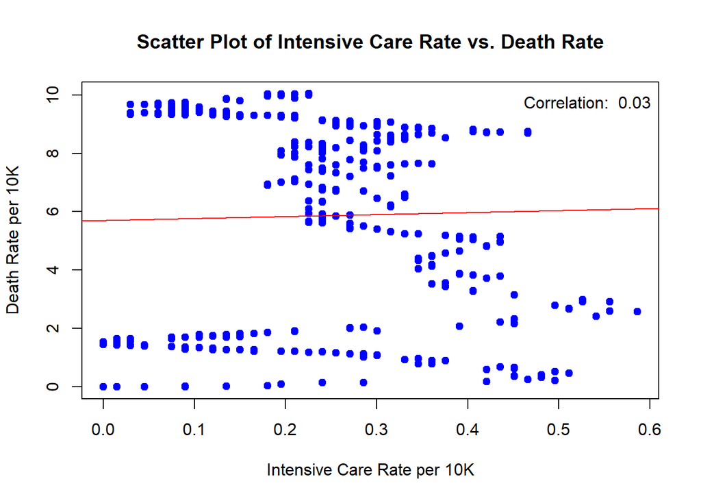

```r
intense_case_deaths_data$DATE_HOSP_NUM <- as.numeric(
  as.Date(
    intense_case_deaths_data$DATE_HOSP,
    format = "%Y-%m-%d"
  )
)


plot(
  intense_case_deaths_data$INTENSE_CARE_10K,
  intense_case_deaths_data$DEATHS_10K,
  col = "blue",
  xlab = "Intensive Care Rate per 10K",
  ylab = "Death Rate per 10K",
  main = "Scatter Plot of Intensive Care Rate vs. Death Rate",
  pch = 19
)

lm_intense_case_deaths <- lm(
  DEATHS_10K ~ INTENSE_CARE_10K,
  data = intense_case_deaths_data
)

abline(
  lm_intense_case_deaths,
  col = "red"
)


legend(
  "topright",
  legend = paste("Correlation: ", round(cor_intense_case_deaths, 2)),
  bty = "n"
)
```

#### TEST DE STUDENT | ETUDE DE REGRESSION ENTRE LE TAUX DE CAS INTENSE ET LE TAUX DE MORTS

Nous allons maintenant réaliser un test de Student pour vérifier si nous pouvons rejeter l’hypothèse nulle concernant le coefficient de corrélation, tout en confirmant que les conclusions statistiques reflètent bien les déductions tirées.

```r
summary_intense_cases_deaths <- summary(lm_intense_case_deaths)

p_val_intense_cases_death <- summary_intense_cases_deaths$coefficients[2, 4]

print(paste("Valeur de P: ", p_val_intense_cases_death))
```

```
## [1] "Valeur de P:  0.507434469699892"
```

### TAUX D’HOSPITALISATIONS PAR SAISON

Pour visualiser mieux l’activiter saisonial des hopitaux on aimerais étudier le taux d’hospitalisations en fonctions des saisons.

```r
hosp_rate_10K <- dbGetQuery(
  connection,
  "SELECT
    AVG((NUM_HOSP/total) * 10000) AS HOSP_RATE,
    CASE
      WHEN MONTH(DATE_HOSP) IN (12, 1, 2) THEN 'Winter'
      WHEN MONTH(DATE_HOSP) IN (3, 4, 5) THEN 'Spring'
      WHEN MONTH(DATE_HOSP) IN (6, 7, 8) THEN 'Summer'
      WHEN MONTH(DATE_HOSP) IN (9, 10, 11) THEN 'Autumn'
    END AS 'SEASONS'
  FROM HOSPITALISATIONS H
  INNER JOIN PROJET_POPU P
    ON H.DEP_ID = P.codeD
  GROUP BY SEASONS
  ORDER BY HOSP_RATE DESC"
)

print(hosp_rate_10K)
```

```
##   HOSP_RATE SEASONS
## 1 2.3642246  Winter
## 2 2.1340599  Spring
## 3 1.0416108  Autumn
## 4 0.6604898  Summer
```

On remarque alors un fort taux d’hospitalisation en Hiver(2.364) et les saisons plus froides qu’en Été(0.660) de 2018 à 2021.

### ETUDE D’HOSPITALISATIONS PENDANT LA PANDEMIE (2019-2020) ET HORS PERIODE COVID (2018-2021)

Pour cela, nous allons étudier le taux d’hospitalisation pendant la période de COVID et hors période COVID pour voir s’il y a eu plus de cas pendant la pandémie ou en dehors de celle-ci.

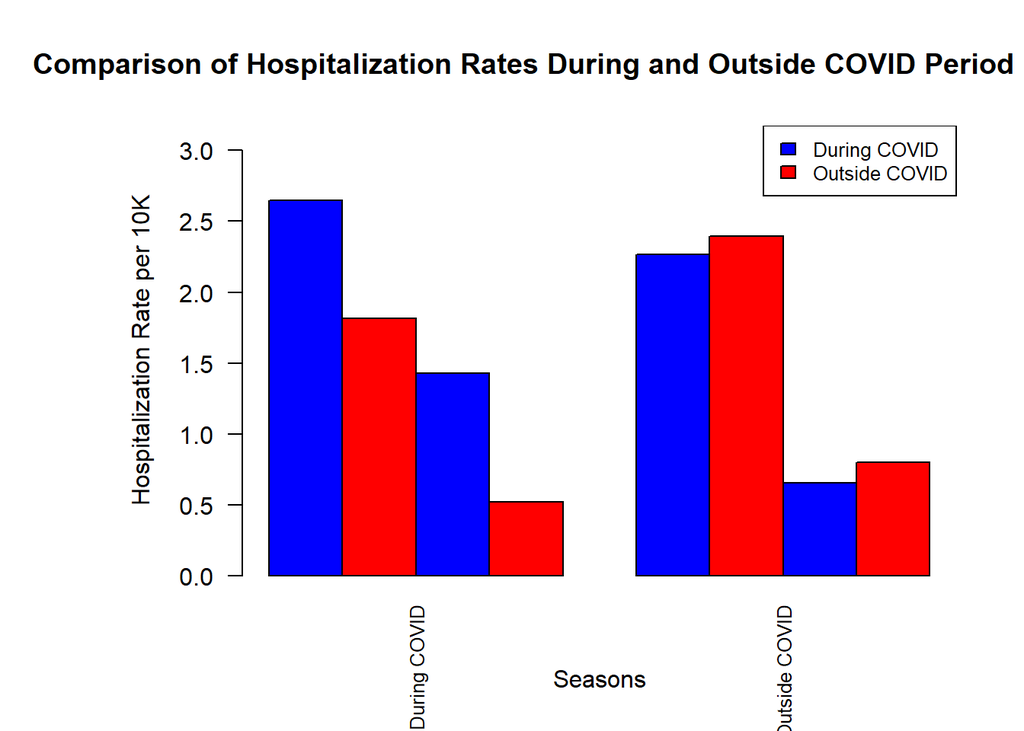

```r
hosp_rate_10K_covid_horscovid <- dbGetQuery(
  connection,
  "WITH COVID_PERIOD AS(
    SELECT
        AVG((NUM_HOSP/ total) * 10000) AS HOSP_RATE_IN_COVID,
        CASE
        WHEN MONTH(DATE_HOSP) IN (12, 1, 2) THEN 'Winter'
        WHEN MONTH(DATE_HOSP) IN (3, 4, 5) THEN 'Spring'
        WHEN MONTH(DATE_HOSP) IN (6, 7, 8) THEN 'Summer'
        WHEN MONTH(DATE_HOSP) IN (9, 10, 11) THEN 'Autumn'
        END AS 'SEASONS'
    FROM HOSPITALISATIONS H
    INNER JOIN PROJET_POPU P
    ON H.DEP_ID = P.codeD
    WHERE DATE_HOSP LIKE '2020-%' OR DATE_HOSP LIKE '2019-%'
    GROUP BY SEASONS
  ), OUTSIDE_COVID AS(
    SELECT
        AVG((NUM_HOSP/ total) * 10000) AS HOSP_RATE_OUTSIDE_COVID,
        CASE
        WHEN MONTH(DATE_HOSP) IN (12, 1, 2) THEN 'Winter'
        WHEN MONTH(DATE_HOSP) IN (3, 4, 5) THEN 'Spring'
        WHEN MONTH(DATE_HOSP) IN (6, 7, 8) THEN 'Summer'
        WHEN MONTH(DATE_HOSP) IN (9, 10, 11) THEN 'Autumn'
        END AS 'SEASONS'
    FROM HOSPITALISATIONS H
    INNER JOIN PROJET_POPU P
    ON H.DEP_ID = P.codeD
    WHERE DATE_HOSP LIKE '2018-%' OR DATE_HOSP LIKE '2021-%'
    GROUP BY SEASONS
  )
  SELECT HOSP_RATE_IN_COVID, HOSP_RATE_OUTSIDE_COVID, CP.SEASONS
  FROM COVID_PERIOD CP
  INNER JOIN OUTSIDE_COVID OC
  ON CP.SEASONS = OC.SEASONS
  ORDER BY HOSP_RATE_IN_COVID DESC, HOSP_RATE_OUTSIDE_COVID DESC"
)

par(mar = c(5, 8, 4, 2) + 0.3)

data_matrix <- matrix(
  c(hosp_rate_10K_covid_horscovid$HOSP_RATE_IN_COVID,
    hosp_rate_10K_covid_horscovid$HOSP_RATE_OUTSIDE_COVID),
  nrow = length(hosp_rate_10K_covid_horscovid$SEASONS),
  byrow = FALSE,
  dimnames = list(
    hosp_rate_10K_covid_horscovid$SEASONS,
    c("During COVID", "Outside COVID")
  )
)


barplot(data_matrix,
  beside = TRUE,
  col = c("blue", "red"),
  ylim = c(0, max(data_matrix) * 1.2),
  xlab = "Seasons",
  ylab = "Hospitalization Rate per 10K",
  main = "Comparison of Hospitalization Rates During and Outside COVID Period by Season",
  cex.names = 0.8,
  las = 2
)

legend("topright",
  legend = c("During COVID", "Outside COVID"),
  fill = c("blue", "red"),
  cex = 0.8
)
```

## ## ETUDE DE VARIABLE TEMPERATURE

### Indice CDD/HDD

Nous allons maintenant étudier la température et, plus précisément, l’indice CDD/HDD pour appuyer la conclusion précédente. L’indice CDD/HDD indique si un bâtiment a besoin d’énergie pour le chauffage ou le refroidissement sur une période donnée. Cette analyse sera représentée graphiquement ci-dessous.

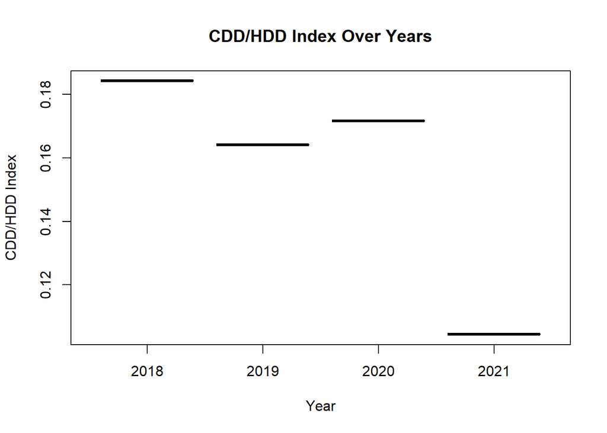

```r
cdd_hdd_query <- "
WITH HEATING_DAYS AS(
  SELECT SUM(18 - MEAN_TEMP) AS HDD, YEAR(DATE_TEMP) AS YEARS
  FROM TEMPERATURES
  WHERE MEAN_TEMP < 18
  GROUP BY YEARS
), COOLING_DAYS AS(
  SELECT SUM(MEAN_TEMP - 18) AS CDD, YEAR(DATE_TEMP) AS YEARS
  FROM TEMPERATURES
  WHERE MEAN_TEMP > 18
  GROUP BY YEARS
)

SELECT
  YEAR(T.DATE_TEMP) AS YEARS,
  CD.CDD/HD.HDD AS `CDD/HDD INDEX`
FROM TEMPERATURES T
LEFT JOIN HEATING_DAYS HD
  ON YEAR(T.DATE_TEMP) = HD.YEARS
LEFT JOIN COOLING_DAYS CD
  ON CD.YEARS = YEAR(T.DATE_TEMP)
GROUP BY YEARS
ORDER BY YEARS ASC
"

cdd_hdd_data <- dbGetQuery(connection, cdd_hdd_query)

cdd_hdd_data$YEARS <- as.factor(cdd_hdd_data$YEARS)

plot(cdd_hdd_data$YEARS, cdd_hdd_data$`CDD/HDD INDEX`,
  type = "b",
  pch = 19,
  lty = 1,
  xlab = "Year",
  ylab = "CDD/HDD Index",
  main = "CDD/HDD Index Over Years"
)
```

## ## CORRELATION ENTRE LA TEMPERATURE ET LE TAUX D’HOSPITALSATION

### COEFFICIENT DE CORRELATION ENTRE LA TEMPERATURE ET LE TAUX D’HOSPITALISATIONS

Nous allons étudier les taux d’hospitalisations et les températures pour examiner la relation entre ces deux variables.

```r
temps_hosp_data <- dbGetQuery(
  connection,
  "SELECT
    MEAN_TEMP,
    ((NUM_HOSP/total) * 10000) AS HOSP_RATE_10K
  FROM TEMPERATURES T
  RIGHT JOIN HOSPITALISATIONS H
    ON H.DEP_ID = T.DEP_ID AND H.DATE_HOSP = T.DATE_TEMP
  INNER JOIN PROJET_POPU P
    ON P.codeD = H.DEP_ID
  WHERE SEX = 0 AND T.DEP_ID IS NOT NULL AND H.DATE_HOSP IS NOT NULL
  GROUP BY DATE_TEMP
  ORDER BY HOSP_RATE_10K DESC, MEAN_TEMP DESC"
)

cor_hosp_temp <- cor(
  temps_hosp_data$MEAN_TEMP,
  temps_hosp_data$HOSP_RATE_10K
)

print(paste("Coefficient of Correlation :", cor_hosp_temp))
```

```
## [1] "Coefficient of Correlation : -0.501494638519282"
```

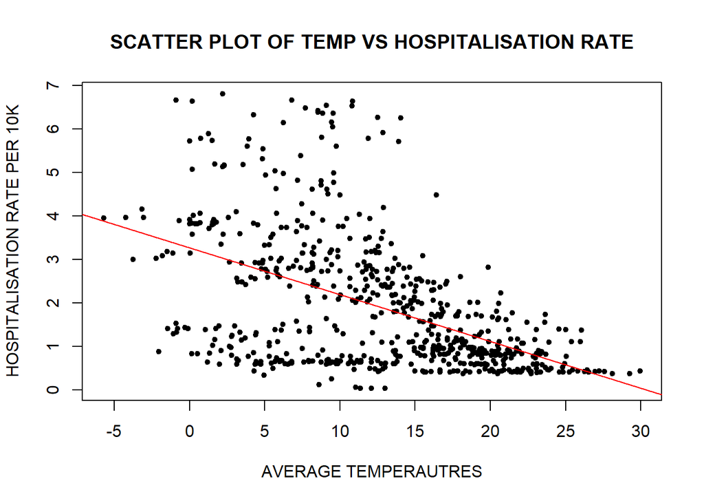

```r
lm_hosp_temp <- lm(
  HOSP_RATE_10K ~ MEAN_TEMP,
  data = temps_hosp_data
)

plot(
  temps_hosp_data$MEAN_TEMP,
  temps_hosp_data$HOSP_RATE_10K,
  main = "SCATTER PLOT OF TEMP VS HOSPITALISATION RATE",
  xlab = "AVERAGE TEMPERAUTRES",
  ylab = "HOSPITALISATION RATE PER 10K",
  pch = 20
)

abline(lm_hosp_temp, col = "red")
```

### ANALYSE DE REGRESSION ENTRE LA TEMPERATURE ET LE TAUX D’HOSPITALISATIONS

Nous cherchons à comprendre et à prédire l’influence de la température sur le taux d’hospitalisations. À travers une analyse de régression, nous établirons un modèle mathématique qui nous permettra de déterminer si des variations de température peuvent être associées à une augmentation ou une diminution du nombre d’hospitalisations.

```r
summary_hosp_temp <- summary(lm_hosp_temp)



print(summary_hosp_temp)
```

```
##
## Call:
## lm(formula = HOSP_RATE_10K ~ MEAN_TEMP, data = temps_hosp_data)
##
## Residuals:
##     Min      1Q  Median      3Q     Max
## -2.6141 -0.6983 -0.1133  0.6168  4.5453
##
## Coefficients:
##              Estimate Std. Error t value Pr(>|t|)
## (Intercept)  3.265193   0.105680    30.9   <2e-16 ***
## MEAN_TEMP   -0.107634   0.007272   -14.8   <2e-16 ***
## ---
## Signif. codes:  0 '***' 0.001 '**' 0.01 '*' 0.05 '.' 0.1 ' ' 1
##
## Residual standard error: 1.318 on 652 degrees of freedom
## Multiple R-squared:  0.2515, Adjusted R-squared:  0.2503
## F-statistic: 219.1 on 1 and 652 DF,  p-value: < 2.2e-16
```

La valeur p obtenue pour le coefficient associé à la température moyenne (MEAN_TEMP) est inférieure à 2e-16, ce qui est extrêmement petit. Cela indique que la relation entre la température moyenne et le taux d’hospitalisation est statistiquement significative. En d’autres termes, nous pouvons rejeter l’hypothèse nulle selon laquelle il n’y a pas de relation entre ces deux variables.

## # CONCLUSION

En somme, cette étude a mis en évidence des liens potentiels entre les températures, les taux d’hospitalisation et les taux de soins intensifs, tout en prenant en compte les effets démographiques et saisonniers. Bien que la température semble avoir une influence modeste sur les hospitalisations, les facteurs démographiques tels que l’âge jouent un rôle plus conséquent dans la gravité des cas de COVID-19. Les analyses statistiques ont révélé des corrélations et ont permis de construire des modèles de régression significatifs, offrant ainsi une meilleure compréhension des dynamiques de la santé publique pendant la pandémie. Cette recherche souligne l’importance de combiner diverses méthodes analytiques pour interpréter les tendances complexes de la santé publique et former des réponses politiques adaptées.

## DECONNEXION

Nous déconnectons de la base de données en signe de bonne pratique.

```r
#dbDisconnect(connection)
```